# examples_1218

A parabola is randomly generated by randomly choosing parameters $a$, $h$, and $k$ in the vertex-form equation:

$$y~=~a(x-h)^2+k$$

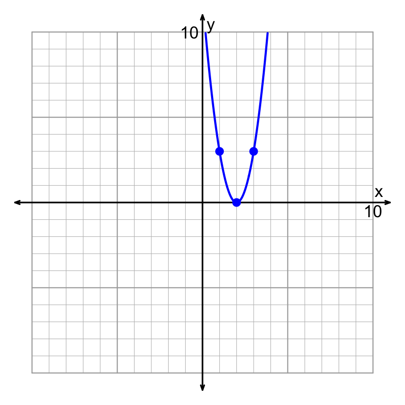

Find the parameters.

- $a=$
- $h=$
- $k=$

How many $x$-intercepts does the parabola have? (Some might not show on the graph.)

To find $a$, you might use [this reference](https://artockthedino.github.io/algtwo2026/u06/1218/Stretched_Parabolas_Reference.html). Notice, if $a$ is negative, the parabola faces down, and if $a$ is positive, the parabola faces up. If $|a|$ is bigger than 1, then the parent $y=x^2$ is stretched vertically. If $|a|$ is less than 1, then the parent $y=x^2$ is shrunk vertically. To find the exact value, you need to look at precisely where the curve intersects the lattice points.

To find $h$ and $k$, you can just find the coordinates of the vertex.

To determine the number of roots...

- If the vertex is on the $x$ axis, there is one root.
- If the parabola opens **up** and the vertex is **above** the $x$ axis, then 0 roots.
- If the parabola opens **down** and the vertex is **above** the $x$ axis, then 2 roots.
- If the parabola opens **up** and the vertex is **below** the $x$ axis, then 2 roots.
- If the parabola opens **down** and the vertex is **below** the $x$ axis, then 0 roots.

A parabola is randomly generated by randomly choosing parameters $a$, $h$, and $k$ in the vertex-form equation:

$$y~=~a(x-h)^2+k$$

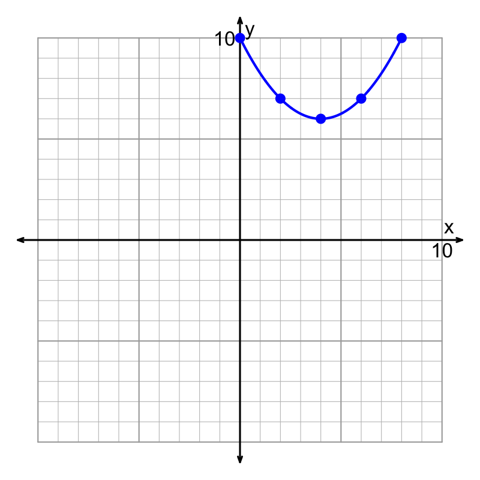

Find the parameters.

- $a=$
- $h=$
- $k=$

How many $x$-intercepts does the parabola have? (Some might not show on the graph.)

To find $a$, you might use [this reference](https://artockthedino.github.io/algtwo2026/u06/1218/Stretched_Parabolas_Reference.html). Notice, if $a$ is negative, the parabola faces down, and if $a$ is positive, the parabola faces up. If $|a|$ is bigger than 1, then the parent $y=x^2$ is stretched vertically. If $|a|$ is less than 1, then the parent $y=x^2$ is shrunk vertically. To find the exact value, you need to look at precisely where the curve intersects the lattice points.

To find $h$ and $k$, you can just find the coordinates of the vertex.

To determine the number of roots...

- If the vertex is on the $x$ axis, there is one root.
- If the parabola opens **up** and the vertex is **above** the $x$ axis, then 0 roots.
- If the parabola opens **down** and the vertex is **above** the $x$ axis, then 2 roots.
- If the parabola opens **up** and the vertex is **below** the $x$ axis, then 2 roots.
- If the parabola opens **down** and the vertex is **below** the $x$ axis, then 0 roots.

A parabola is randomly generated by randomly choosing parameters $a$, $h$, and $k$ in the vertex-form equation:

$$y~=~a(x-h)^2+k$$

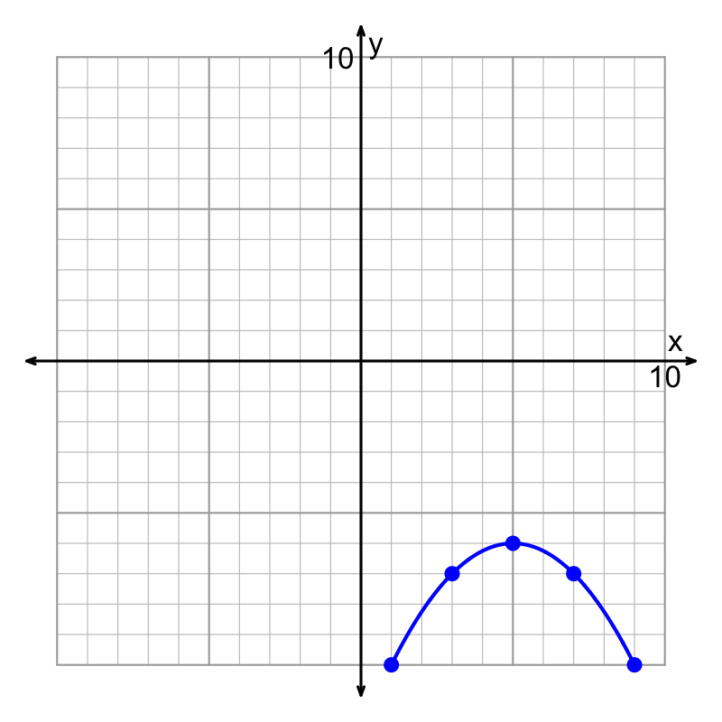

Find the parameters.

- $a=$
- $h=$
- $k=$

How many $x$-intercepts does the parabola have? (Some might not show on the graph.)

To find $a$, you might use [this reference](https://artockthedino.github.io/algtwo2026/u06/1218/Stretched_Parabolas_Reference.html). Notice, if $a$ is negative, the parabola faces down, and if $a$ is positive, the parabola faces up. If $|a|$ is bigger than 1, then the parent $y=x^2$ is stretched vertically. If $|a|$ is less than 1, then the parent $y=x^2$ is shrunk vertically. To find the exact value, you need to look at precisely where the curve intersects the lattice points.

To find $h$ and $k$, you can just find the coordinates of the vertex.

To determine the number of roots...

- If the vertex is on the $x$ axis, there is one root.
- If the parabola opens **up** and the vertex is **above** the $x$ axis, then 0 roots.
- If the parabola opens **down** and the vertex is **above** the $x$ axis, then 2 roots.
- If the parabola opens **up** and the vertex is **below** the $x$ axis, then 2 roots.
- If the parabola opens **down** and the vertex is **below** the $x$ axis, then 0 roots.

A parabola is randomly generated by randomly choosing parameters $a$, $h$, and $k$ in the vertex-form equation:

$$y~=~a(x-h)^2+k$$

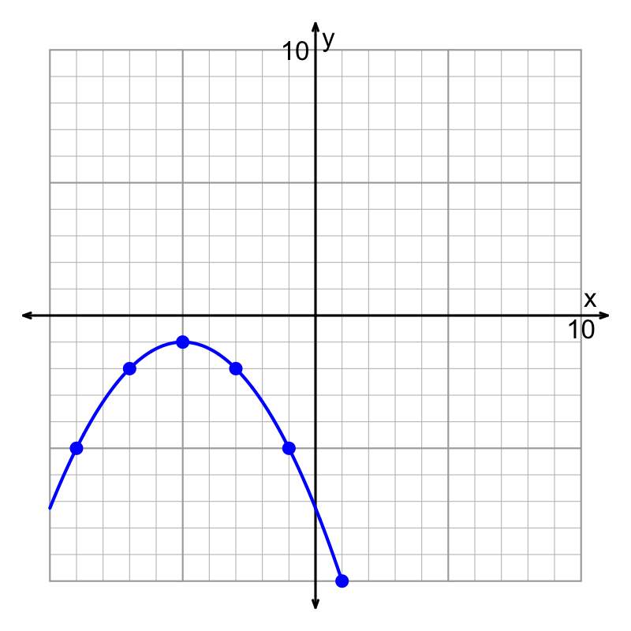

Find the parameters.

- $a=$
- $h=$
- $k=$

How many $x$-intercepts does the parabola have? (Some might not show on the graph.)

To find $a$, you might use [this reference](https://artockthedino.github.io/algtwo2026/u06/1218/Stretched_Parabolas_Reference.html). Notice, if $a$ is negative, the parabola faces down, and if $a$ is positive, the parabola faces up. If $|a|$ is bigger than 1, then the parent $y=x^2$ is stretched vertically. If $|a|$ is less than 1, then the parent $y=x^2$ is shrunk vertically. To find the exact value, you need to look at precisely where the curve intersects the lattice points.

To find $h$ and $k$, you can just find the coordinates of the vertex.

To determine the number of roots...

- If the vertex is on the $x$ axis, there is one root.
- If the parabola opens **up** and the vertex is **above** the $x$ axis, then 0 roots.
- If the parabola opens **down** and the vertex is **above** the $x$ axis, then 2 roots.
- If the parabola opens **up** and the vertex is **below** the $x$ axis, then 2 roots.
- If the parabola opens **down** and the vertex is **below** the $x$ axis, then 0 roots.

A parabola is randomly generated by randomly choosing parameters $a$, $h$, and $k$ in the vertex-form equation:

$$y~=~a(x-h)^2+k$$

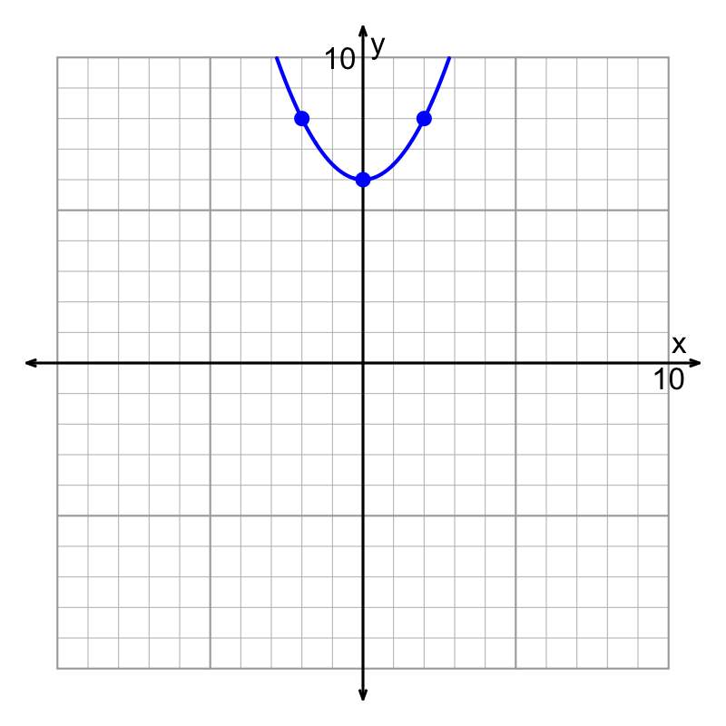

Find the parameters.

- $a=$
- $h=$
- $k=$

How many $x$-intercepts does the parabola have? (Some might not show on the graph.)

To find $a$, you might use [this reference](https://artockthedino.github.io/algtwo2026/u06/1218/Stretched_Parabolas_Reference.html). Notice, if $a$ is negative, the parabola faces down, and if $a$ is positive, the parabola faces up. If $|a|$ is bigger than 1, then the parent $y=x^2$ is stretched vertically. If $|a|$ is less than 1, then the parent $y=x^2$ is shrunk vertically. To find the exact value, you need to look at precisely where the curve intersects the lattice points.

To find $h$ and $k$, you can just find the coordinates of the vertex.

To determine the number of roots...

- If the vertex is on the $x$ axis, there is one root.
- If the parabola opens **up** and the vertex is **above** the $x$ axis, then 0 roots.
- If the parabola opens **down** and the vertex is **above** the $x$ axis, then 2 roots.
- If the parabola opens **up** and the vertex is **below** the $x$ axis, then 2 roots.
- If the parabola opens **down** and the vertex is **below** the $x$ axis, then 0 roots.

A parabola is randomly generated by randomly choosing parameters $a$, $h$, and $k$ in the vertex-form equation:

$$y~=~a(x-h)^2+k$$

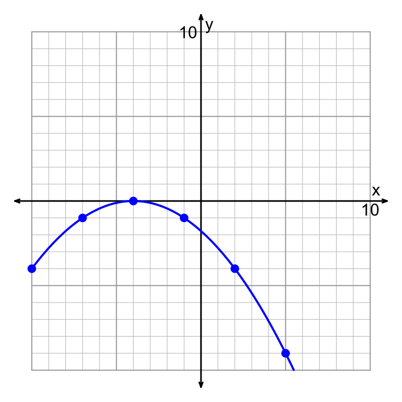

Find the parameters.

- $a=$
- $h=$
- $k=$

How many $x$-intercepts does the parabola have? (Some might not show on the graph.)

To find $a$, you might use [this reference](https://artockthedino.github.io/algtwo2026/u06/1218/Stretched_Parabolas_Reference.html). Notice, if $a$ is negative, the parabola faces down, and if $a$ is positive, the parabola faces up. If $|a|$ is bigger than 1, then the parent $y=x^2$ is stretched vertically. If $|a|$ is less than 1, then the parent $y=x^2$ is shrunk vertically. To find the exact value, you need to look at precisely where the curve intersects the lattice points.

To find $h$ and $k$, you can just find the coordinates of the vertex.

To determine the number of roots...

- If the vertex is on the $x$ axis, there is one root.
- If the parabola opens **up** and the vertex is **above** the $x$ axis, then 0 roots.
- If the parabola opens **down** and the vertex is **above** the $x$ axis, then 2 roots.
- If the parabola opens **up** and the vertex is **below** the $x$ axis, then 2 roots.
- If the parabola opens **down** and the vertex is **below** the $x$ axis, then 0 roots.

A parabola is randomly generated by randomly choosing parameters $a$, $h$, and $k$ in the vertex-form equation:

$$y~=~a(x-h)^2+k$$

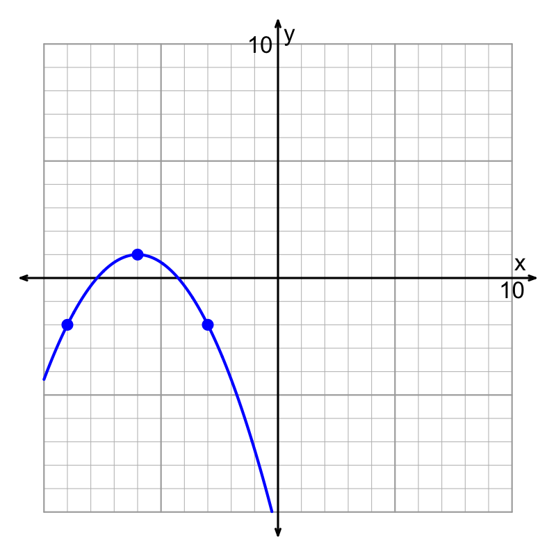

Find the parameters.

- $a=$
- $h=$
- $k=$

How many $x$-intercepts does the parabola have? (Some might not show on the graph.)

To find $a$, you might use [this reference](https://artockthedino.github.io/algtwo2026/u06/1218/Stretched_Parabolas_Reference.html). Notice, if $a$ is negative, the parabola faces down, and if $a$ is positive, the parabola faces up. If $|a|$ is bigger than 1, then the parent $y=x^2$ is stretched vertically. If $|a|$ is less than 1, then the parent $y=x^2$ is shrunk vertically. To find the exact value, you need to look at precisely where the curve intersects the lattice points.

To find $h$ and $k$, you can just find the coordinates of the vertex.

To determine the number of roots...

- If the vertex is on the $x$ axis, there is one root.
- If the parabola opens **up** and the vertex is **above** the $x$ axis, then 0 roots.
- If the parabola opens **down** and the vertex is **above** the $x$ axis, then 2 roots.
- If the parabola opens **up** and the vertex is **below** the $x$ axis, then 2 roots.
- If the parabola opens **down** and the vertex is **below** the $x$ axis, then 0 roots.

A parabola is randomly generated by randomly choosing parameters $a$, $h$, and $k$ in the vertex-form equation:

$$y~=~a(x-h)^2+k$$

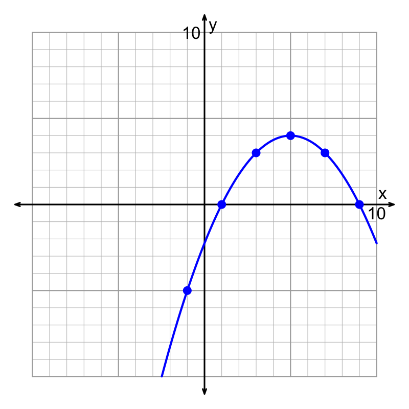

Find the parameters.

- $a=$
- $h=$
- $k=$

How many $x$-intercepts does the parabola have? (Some might not show on the graph.)

To find $a$, you might use [this reference](https://artockthedino.github.io/algtwo2026/u06/1218/Stretched_Parabolas_Reference.html). Notice, if $a$ is negative, the parabola faces down, and if $a$ is positive, the parabola faces up. If $|a|$ is bigger than 1, then the parent $y=x^2$ is stretched vertically. If $|a|$ is less than 1, then the parent $y=x^2$ is shrunk vertically. To find the exact value, you need to look at precisely where the curve intersects the lattice points.

To find $h$ and $k$, you can just find the coordinates of the vertex.

To determine the number of roots...

- If the vertex is on the $x$ axis, there is one root.
- If the parabola opens **up** and the vertex is **above** the $x$ axis, then 0 roots.
- If the parabola opens **down** and the vertex is **above** the $x$ axis, then 2 roots.
- If the parabola opens **up** and the vertex is **below** the $x$ axis, then 2 roots.
- If the parabola opens **down** and the vertex is **below** the $x$ axis, then 0 roots.